# Trait based analysis Redundancy of reproductive and wood density traits

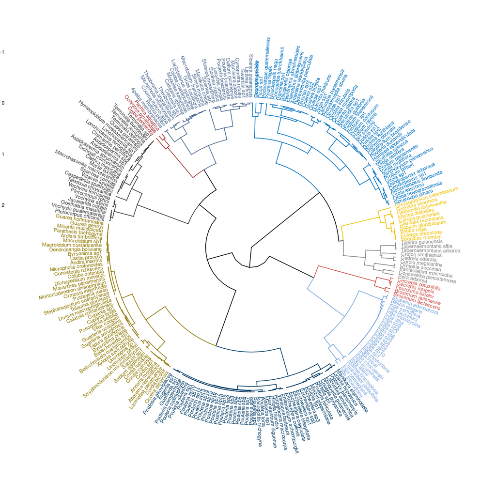

```r
library(factoextra)
library(ggsci)
fviz_dend(cluster,
          k = cluster_groups$Best.nc[1],
          k_colors = "jco",
          repel = TRUE,
          horiz = TRUE,
          type = "circular")
```

We can also visualize the groups using s.class, with respect to the PCoA:

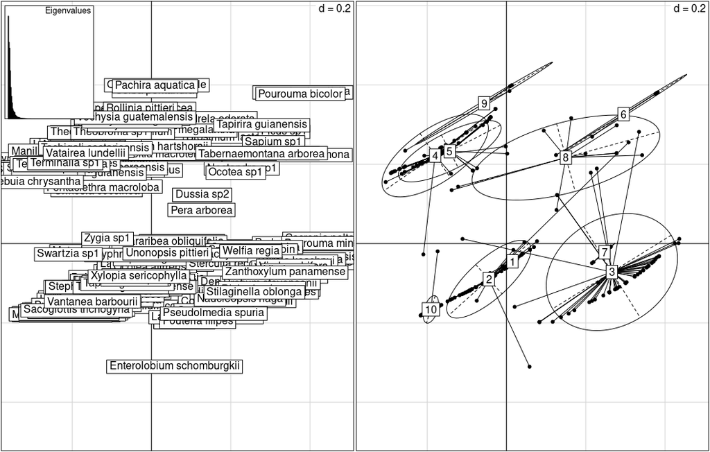

```r
par(mfrow = c(1, 2))
scatter(pcoa_all)
s.class(pcoa_all$li, as.factor(cluster_groups$Best.partition), cpoint = 1)
```

## 3.8 Some real data with the function trova

The function allows to compute species dissimilarity not only using species means, but also considering overlap of trait values between species by using the standard deviation of a give trait.

```r
data_cleaned_dummy <- data_cleaned_dummy[, c(1:4,14)]
list_dummy <- list(data_cleaned_dummy[, 1:4])
names(list_dummy) <- "disp_symd"

dissims <- trova(species.names = rownames(data_cleaned_dummy),
                 # needs mean and sd
                 gaussian.data = wd,
                 multiple.category = list_dummy)
```

## 3.9 The gawdis function

The dissimilarity obtained can be computed in order to attain a quasi-identical contribution of individual variables (e.g. traits) or group of associated variables (on variables reflecting similar information, e.g. multiple leaf traits)

```r
dummy$trait
```

```
    num1 num2 fac1 fac2 ord1 ord2 bin1 bin2
sp1  9.0  4.5    A    X    3    2    0    1
sp2  8.1  6.0    A    Z <NA>    1    0    1
sp3   NA  2.3    C    Y    5    3    1    1
sp4  3.2  5.4    B    Z    1    7    0    0
sp5  5.8  1.2    C    X    2    6   NA    0
sp6  3.4  8.5    C    Y    2    1    1    1
sp7  7.5  2.1    B    X    3    2    1    0
sp8  4.3  6.5 <NA>    Z    1    3    0    1
```

```r
equalcont <- gawdis(data_cleaned,
                    w.type = "optimized",
                    opti.maxiter = 300)

equalcont <- round(equalcont,3)
attr(equalcont, "correls")
attr(equalcont, "weights")
```

[output not shown]

## The function gawdis: grouping traits

```r
# load shade house experiment
load("../../data_test_shadehouse.RData")

traits <-
    data_complete %>%
        unite("group", 1:4, sep = "_") %>%
        column_to_rownames("group") %>%
        select(8:16,20,21)
```

```r
straightgowdis_2 <- gawdis(traits, w.type = "equal", silent = T)
cors_gow <- attr(straightgowdis_2, "correls")
```

```r
gaw_groups <- gawdis(traits,
                     w.type = "optimized",
                     opti.maxiter = 300,
                     groups.weight = T,
                     groups = c(1, 1, 1, 2, 2, 2, 2, 3, 3, 2))
```

```r
cors_gaw_gr <- attr(gaw_groups, "correls")
ncol(traits)

cors_gaw_gr[11] <- attr(gaw_groups, "group.correls")[1]
names(cors_gaw_gr)[11] <- "phys"

cors_gaw_gr[12] <- attr(gaw_groups, "group.correls")[2]
names(cors_gaw_gr)[12] <- "leaf_traits"

cors_gaw_gr[13] <- attr(gaw_groups, "group.correls")[3]
names(cors_gaw_gr)[13] <- "isotopes"
```